# TUGAS NEW DELHI AQI

Raihanah Nurkhalishah

2025-09-15

```r
library(dLagM)
library(dynlm)
library(MLmetrics)
library(lmtest)
library(car)
AQI = read.csv("C:/Users/Imam/Downloads/NewDelhi_Air_quality.csv")
View(AQI)
```

```r
str(AQI)
```

```
## 'data.frame':    72 obs. of  12 variables:
##  $ X              : int  0 1 2 3 4 5 6 7 8 9 ...
##  $ AQI            : num  30.2 28.2 26.6 25 26 26 26 24 23 24 ...
##  $ CO             : num  199 198 199 202 205 ...
##  $ datetime       : chr  "2022-10-21:18" "2022-10-21:19" "2022-10-21:20" "2022-10-21:21" ...
##  $ no2            : num  0.0469 0.0465 0.0469 0.0482 0.0489 ...
##  $ o3             : num  55.8 54.9 54.6 55.1 55.8 ...
##  $ pm10           : num  10.5 10.7 11.2 11.1 10.4 ...
##  $ pm25           : num  5.64 4.62 3.52 2.23 1.98 ...
##  $ so2            : num  0.387 0.41 0.402 0.376 0.339 ...
##  $ timestamp_local: chr  "2022-10-21T23:00:00" "2022-10-22T00:00:00" "2022-10-22T01:00:00" "2022-10-22T02:00:00" ...
##  $ timestamp_utc  : chr  "2022-10-21T18:00:00" "2022-10-21T19:00:00" "2022-10-21T20:00:00" "2022-10-21T21:00:00" ...
##  $ ts             : int  1666375200 1666378800 1666382400 1666386000 1666389600 1666393200 1666396800 1666400400 1666404000 1666407600 ...
```

# 1 Eksplorasi

```r
#mencari korelasi antar peubah
data_pollutants <- AQI[, c("AQI", "CO", "no2", "o3", "pm10", "pm25", "so2")]
cor_matrix <- cor(data_pollutants, use = "complete.obs")

cor_with_aqi <- cor_matrix["AQI", -1]
cor_with_aqi_sorted <- sort(cor_with_aqi, decreasing = TRUE)
print(cor_with_aqi_sorted)
```

```
##          o3          CO         no2        pm10        pm25         so2
##  0.97359901  0.79763320  0.73765472  0.08257568 -0.34665524 -0.74247813
```

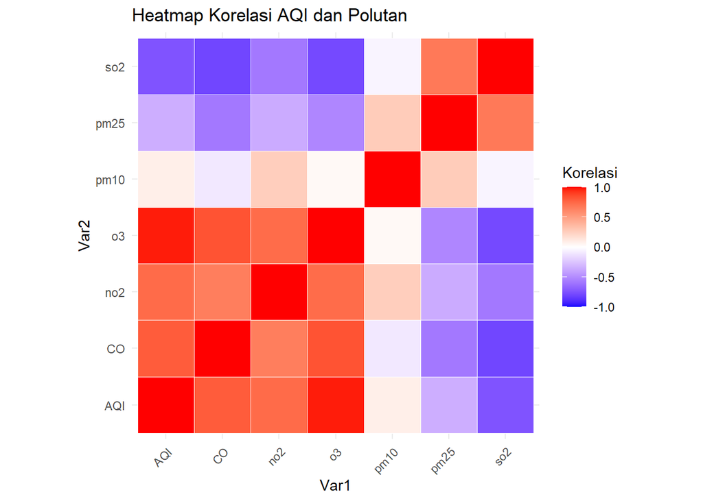

```r
library(ggplot2)
library(reshape2)

# hitung korelasi
cor_matrix <- cor(AQI[, c("AQI", "CO", "no2", "o3", "pm10", "pm25", "so2")],
                  use = "complete.obs")

# ubah jadi long format
cor_melt <- melt(cor_matrix)

# plot heatmap
ggplot(cor_melt, aes(x = Var1, y = Var2, fill = value)) +
  geom_tile(color = "white") +
  scale_fill_gradient2(low = "blue", high = "red", mid = "white",
                       midpoint = 0, limit = c(-1,1), space = "Lab",
                       name = "Korelasi") +
  theme_minimal() +
  theme(axis.text.x = element_text(angle = 45, vjust = 1, hjust = 1)) +
  coord_fixed() +
  labs(title = "Heatmap Korelasi AQI dan Polutan")
```

berdasarkan hasil eksplorasi, didapatkan peubah O3 memiliki korelasi tertinggi. Oleh karena itu, saya memilih O3 sebagai variabel X.

# 2 Memilih Variabel O3 & Eksplorasi

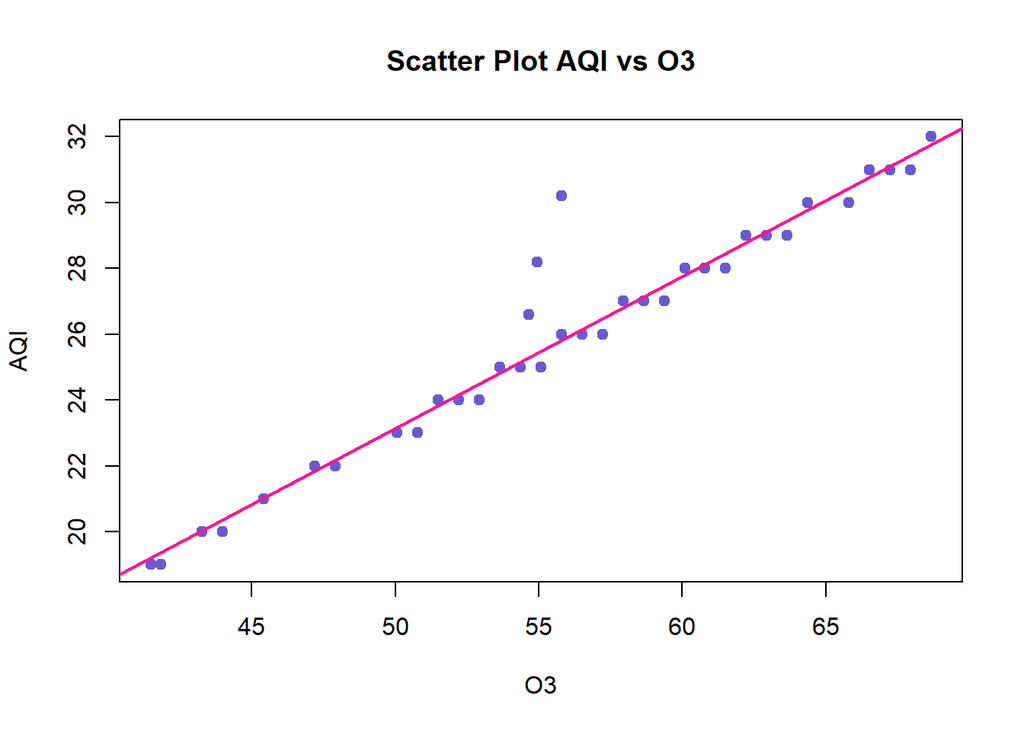

```r
# Membuat Scatter plot
plot(AQI$o3, AQI$AQI,
     main = "Scatter Plot AQI vs O3",
     xlab = "O3",
     ylab = "AQI",
     pch = 19, col = "slateblue")
abline(lm(AQI ~ o3, data = AQI), col = "deeppink", lwd = 2)
```

```r
cor.test(AQI$o3, AQI$AQI, use = "complete.obs")
```

```
##
##  Pearson's product-moment correlation
##
## data:  AQI$o3 and AQI$AQI
## t = 35.685, df = 70, p-value < 2.2e-16
## alternative hypothesis: true correlation is not equal to 0
## 95 percent confidence interval:
##  0.9580123 0.9834485
## sample estimates:
##      cor
## 0.973599
```

Berdasarkan hasil korelasi Pearson didapatkan korelasi AQI dan O3 sebesar 97%.

## 2.1 UJI ASUMSI

```r
model_O3 <- lm(AQI ~ o3, data = AQI)
summary(model_O3)
```

```
##
## Call:
## lm(formula = AQI ~ o3, data = AQI)
##
## Residuals:
##     Min      1Q  Median      3Q     Max
## -0.5039 -0.4436 -0.1381  0.1810  4.3810
##
## Coefficients:
##             Estimate Std. Error t value Pr(>|t|)
## (Intercept)  0.02128    0.73771   0.029    0.977
## o3           0.46241    0.01296  35.685   <2e-16 ***
## ---
## Signif. codes:  0 '***' 0.001 '**' 0.01 '*' 0.05 '.' 0.1 ' ' 1
##
## Residual standard error: 0.7022 on 70 degrees of freedom
## Multiple R-squared:  0.9479, Adjusted R-squared:  0.9472
## F-statistic:  1273 on 1 and 70 DF,  p-value: < 2.2e-16
```

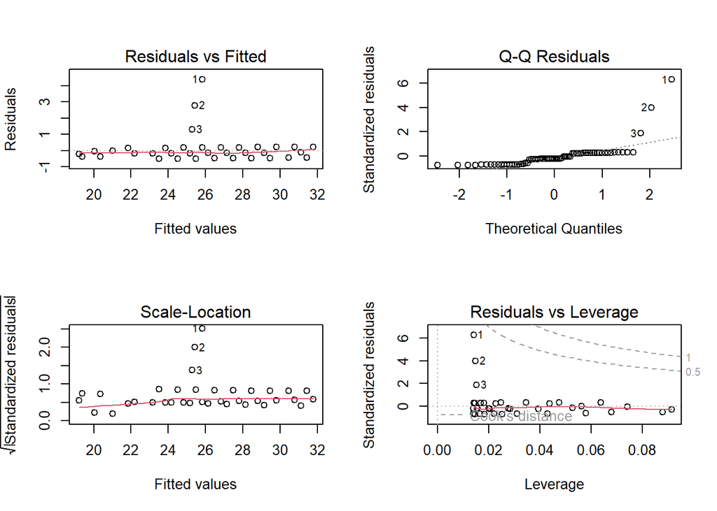

```r
par(mfrow=c(2,2))
plot(model_O3)
```

```r
shapiro.test(residuals(model_O3))
```

```
##
##  Shapiro-Wilk normality test
##
## data:  residuals(model_O3)
## W = 0.51931, p-value = 5.517e-14
```

tidak normal, tdk terpenuhi

```r
library(lmtest)
dwtest(model_O3)
```

```
##
##  Durbin-Watson test
##
## data:  model_O3
## DW = 0.54636, p-value = 3.207e-14
## alternative hypothesis: true autocorrelation is greater than 0
```

Ada autokorelasi, tdk terpenuhi

```r
bptest(model_O3)
```

```
##
##  studentized Breusch-Pagan test
##
## data:  model_O3
## BP = 0.039736, df = 1, p-value = 0.842
```

tidak ada heteroskedastisitas, terpenuhi

# 3 Split Data

```r
n <- nrow(AQI)
n_train <- floor(0.7 * n)   # 70% training
train_O3 <- AQI[1:n_train, ]
test_O3  <- AQI[(n_train + 1):n, ]
nrow(train_O3); nrow(test_O3)
```

```
## [1] 50
```

```
## [1] 22
```

```r
head(train_O3); head(test_O3)
```

```
##   X  AQI       CO      datetime        no2       o3      pm10     pm25
## 1 0 30.2 198.6027 2022-10-21:18 0.04685717 55.78995 10.486722 5.637410
## 2 1 28.2 197.6013 2022-10-21:19 0.04645554 54.93164 10.719325 4.618169
## 3 2 26.6 198.6027 2022-10-21:20 0.04685717 54.64554 11.155578 3.520902
## 4 3 25.0 201.9405 2022-10-21:21 0.04819594 55.07469 11.116206 2.225919
## 5 4 26.0 205.2784 2022-10-21:22 0.04886533 55.78995 10.405250 1.979471
## 6 5 26.0 208.6163 2022-10-21:23 0.05020411 56.50520  9.402518 1.792677
##         so2     timestamp_local       timestamp_utc         ts
## 1 0.3874302 2022-10-21T23:00:00 2022-10-21T18:00:00 1666375200
## 2 0.4097819 2022-10-22T00:00:00 2022-10-21T19:00:00 1666378800
## 3 0.4023313 2022-10-22T01:00:00 2022-10-21T20:00:00 1666382400
## 4 0.3762543 2022-10-22T02:00:00 2022-10-21T21:00:00 1666386000
## 5 0.3390014 2022-10-22T03:00:00 2022-10-21T22:00:00 1666389600
## 6 0.3129244 2022-10-22T04:00:00 2022-10-21T23:00:00 1666393200
```

```
##     X AQI       CO      datetime        no2       o3     pm10     pm25
## 51 50  27 200.2716 2022-10-23:20 0.04618778 59.36623 8.654108 2.283845
## 52 51  28 200.2716 2022-10-23:21 0.04752655 60.08148 8.514708 2.195546
## 53 52  28 200.2716 2022-10-23:22 0.04685717 60.08148 7.923108 2.066149
## 54 53  27 200.2716 2022-10-23:23 0.04618778 59.36623 7.097172 2.059171
## 55 54  27 198.6027 2022-10-24:00 0.04551839 58.65097 6.815780 2.072363
## 56 55  26 198.6027 2022-10-24:01 0.04752655 57.22046 7.661589 2.102422
##          so2     timestamp_local       timestamp_utc         ts
## 51 0.3874302 2022-10-24T01:00:00 2022-10-23T20:00:00 1666555200
## 52 0.3762543 2022-10-24T02:00:00 2022-10-23T21:00:00 1666558800
## 53 0.3650784 2022-10-24T03:00:00 2022-10-23T22:00:00 1666562400
## 54 0.3688037 2022-10-24T04:00:00 2022-10-23T23:00:00 1666566000
## 55 0.3762543 2022-10-24T05:00:00 2022-10-24T00:00:00 1666569600
## 56 0.3837049 2022-10-24T06:00:00 2022-10-24T01:00:00 1666573200
```

```r
trainO3.ts<-ts(train_O3)
testO3.ts<-ts(test_O3)
AQI.ts<-ts(AQI)
```

# 4 Pemodelan

## 4.1 Model Koyck

```r
model.koyck.O3 <- koyckDlm(x = train_O3$o3, y = train_O3$AQI)
summary(model.koyck.O3)
```

```
##
## Call:
## "Y ~ (Intercept) + Y.1 + X.t"
##
## Residuals:
##       Min        1Q    Median        3Q       Max
## -1.151096 -0.263820  0.003836  0.244093  1.076568
##
## Coefficients:
##             Estimate Std. Error t value Pr(>|t|)
## (Intercept)  0.60533    0.94314   0.642    0.524
## Y.1          0.41624    0.08209   5.071 6.93e-06 ***
## X.t          0.25928    0.04101   6.322 9.52e-08 ***
## ---
## Signif. codes:  0 '***' 0.001 '**' 0.01 '*' 0.05 '.' 0.1 ' ' 1
##
## Residual standard error: 0.5094 on 46 degrees of freedom
## Multiple R-Squared: 0.9512,  Adjusted R-squared: 0.9491
## Wald test: 410.3 on 2 and 46 DF,  p-value: < 2.2e-16
##
## Diagnostic tests:
## NULL
##
##                             alpha      beta       phi
## Geometric coefficients:  1.036947 0.2592833 0.4162377
```

```r
AIC(model.koyck.O3)
```

```
## [1] 77.85802
```

```r
BIC(model.koyck.O3)
```

```
## [1] 85.4253
```

### 4.1.1 Peramalan dan Akurasi

```r
fore.koyck.O3 <- forecast(model = model.koyck.O3, x=test_O3$o3, h=22)
fore.koyck.O3
```

```
## $forecasts
##  [1] 27.23642 27.52028 27.63843 27.50216 27.25998 26.78827 25.85011 24.53235
##  [9] 23.24203 22.05586 21.19122 20.27497 19.80086 20.06715 20.73436 21.01207
## [17] 21.12767 21.63942 23.15060 24.89234 26.35913 27.34057
##
## $call
## forecast.koyckDlm(model = model.koyck.O3, x = test_O3$o3, h = 22)
##
## attr(,"class")
## [1] "forecast.koyckDlm" "dLagM"
```

```r
mape.koyck.O3 <- MAPE(fore.koyck.O3$forecasts, test_O3$AQI)
mape.koyck.O3
```

```
## [1] 0.02899356
```

```r
GoF(model.koyck.O3)
```

```
##                 n       MAE          MPE       MAPE      sMAPE      MASE
## model.koyck.O3 49 0.3805309 -0.000502754 0.01419385 0.01416685 0.5854322
##                     MSE      MRAE    GMRAE
## model.koyck.O3 0.243606 593606558 7877.206
```

## 4.2 Regression with Distributed Lag

```r
# Distributed Lag q=1
model.dlm1.o3 <- dlm(x = train_O3$o3, y = train_O3$AQI, q = 1)
summary(model.dlm1.o3)
```

```
##
## Call:
## lm(formula = model.formula, data = design)
##
## Residuals:
##      Min       1Q   Median       3Q      Max
## -0.55389 -0.38049 -0.07901  0.18756  2.74910
##
## Coefficients:
##             Estimate Std. Error t value Pr(>|t|)
## (Intercept) 0.534621   0.963167   0.555    0.582
## x.t         0.447899   0.051312   8.729 2.55e-11 ***
## x.1         0.005601   0.051111   0.110    0.913
## ---
## Signif. codes:  0 '***' 0.001 '**' 0.01 '*' 0.05 '.' 0.1 ' ' 1
##
## Residual standard error: 0.5419 on 46 degrees of freedom
## Multiple R-squared:  0.9448, Adjusted R-squared:  0.9424
## F-statistic: 393.5 on 2 and 46 DF,  p-value: < 2.2e-16
##
## AIC and BIC values for the model:
##        AIC      BIC
## 1 83.92339 91.49068
```

```r
# Distributed Lag q=2
model.dlm2.o3 <- dlm(x = train_O3$o3, y = train_O3$AQI, q = 2)
summary(model.dlm2.o3)
```

```
##
## Call:
## lm(formula = model.formula, data = design)
##
## Residuals:
##      Min       1Q   Median       3Q      Max
## -0.44587 -0.36865 -0.05142  0.24389  1.38587
##
## Coefficients:
##               Estimate Std. Error t value Pr(>|t|)
## (Intercept) -0.0104664  0.7181482  -0.015    0.988
## x.t          0.4695153  0.0588098   7.984 4.26e-10 ***
## x.1         -0.0004461  0.1062228  -0.004    0.997
## x.2         -0.0073098  0.0582653  -0.125    0.901
## ---
## Signif. codes:  0 '***' 0.001 '**' 0.01 '*' 0.05 '.' 0.1 ' ' 1
##
## Residual standard error: 0.3583 on 44 degrees of freedom
## Multiple R-squared:  0.9768, Adjusted R-squared:  0.9752
## F-statistic:   618 on 3 and 44 DF,  p-value: < 2.2e-16
##
## AIC and BIC values for the model:
##       AIC     BIC
## 1 43.4975 52.8535
```

```r
# Distributed Lag q=3
model.dlm3.o3 <- dlm(x = train_O3$o3, y = train_O3$AQI, q = 3)
summary(model.dlm3.o3)
```

```
##
## Call:
## lm(formula = model.formula, data = design)
##
## Residuals:
##      Min       1Q   Median       3Q      Max
## -0.43651 -0.33756 -0.02392  0.27875  0.34597
##
## Coefficients:
##             Estimate Std. Error t value Pr(>|t|)
## (Intercept) -0.35214    0.63116  -0.558    0.580
## x.t          0.46682    0.04958   9.416 6.55e-12 ***
## x.1          0.02707    0.10569   0.256    0.799
## x.2         -0.03772    0.10583  -0.356    0.723
## x.3          0.01088    0.04948   0.220    0.827
## ---
## Signif. codes:  0 '***' 0.001 '**' 0.01 '*' 0.05 '.' 0.1 ' ' 1
##
## Residual standard error: 0.2946 on 42 degrees of freedom
## Multiple R-squared:  0.985,  Adjusted R-squared:  0.9836
## F-statistic: 690.4 on 4 and 42 DF,  p-value: < 2.2e-16
##
## AIC and BIC values for the model:
##        AIC      BIC
## 1 25.20655 36.30743
```

```r
results.DLO3 <- data.frame(
  Model = c("q=1", "q=2", "q=3"),
  AIC = c(AIC(model.dlm1.o3), AIC(model.dlm2.o3), AIC(model.dlm3.o3)),
  BIC = c(BIC(model.dlm1.o3), BIC(model.dlm2.o3), BIC(model.dlm3.o3))
)
```

[output not shown]

```r
print(results.DLO3)
```

```
##   Model      AIC      BIC
## 1   q=1 83.92339 91.49068
## 2   q=2 43.49750 52.85350
## 3   q=3 25.20655 36.30743
```

### 4.2.1 Peramalan dan Akurasi

```r
fore.dlm1.o3 <- forecast(model = model.dlm1.o3, x=test_O3$o3, h=22)
fore.dlm1.o3
```

```
## $forecasts
##  [1] 27.45317 27.77754 27.78154 27.46118 27.13681 26.49208 25.20262 23.58479
##  [9] 22.28331 21.14602 20.49127 19.52217 19.34997 20.14888 21.11998 21.13200
## [17] 21.13200 21.93290 24.18545 26.13566 27.44115 28.09790
##
## $call
## forecast.dlm(model = model.dlm1.o3, x = test_O3$o3, h = 22)
##
## attr(,"class")
## [1] "forecast.dlm" "dLagM"
```

```r
mape.dlm1.o3 <- MAPE(fore.dlm1.o3$forecasts, test_O3$AQI)
mape.dlm1.o3
```

```
## [1] 0.01177231
```

```r
GoF(model.dlm1.o3)
```

```
##                n       MAE          MPE      MAPE      sMAPE      MASE      MSE
## model.dlm1.o3 49 0.3358866 -0.000381022 0.0124124 0.01250035 0.5167486 0.275706
##                     MRAE    GMRAE
## model.dlm1.o3 1019806205 8190.926
```

### 4.2.2 Lag Optimum

```r
finiteDLMauto(formula = AQI ~ o3,
              data = data.frame(train_O3), q.min = 1, q.max = 10,
              model.type = "dlm", error.type = "AIC", trace = TRUE)
```

```
##    q - k    MASE      AIC      BIC     GMRAE   MBRAE R.Adj.Sq  Ljung-Box
## 10    10 0.34331 19.45847 41.41390 19619.244 0.50116  0.98539 0.46127017
## 5      5 0.37812 24.78482 39.23812  9355.450 0.49430  0.98434 0.20604139
## 3      3 0.40011 25.20655 36.30743  9729.294 0.49427  0.98359 0.12399990
## 4      4 0.39940 25.99508 38.79557 11892.043 0.49818  0.98350 0.19093971
## 9      9 0.38409 26.57473 47.13759 16265.748 0.50815  0.98315 0.95495240
## 8      8 0.39782 26.86728 45.98164 14081.125 0.51264  0.98407 0.50694285
## 6      6 0.37517 27.46132 43.51903  7156.215 0.48223  0.98378 0.21904550
## 7      7 0.38804 28.54189 46.15389  7928.706 0.48872  0.98375 0.38644874
## 2      2 0.43314 43.49750 52.85350  8904.039 0.48730  0.97524 0.09404448
## 1      1 0.51675 83.92339 91.49068  8190.926 0.40446  0.94238 0.16554905
```

Berdasarkan output tersebut, lag optimum didapatkan ketika lag=10. Selanjutnya dilakukan pemodelan untuk lag=10

```r
model.dlm10 <- dlm(x = train_O3$o3,y = train_O3$AQI , q = 10)
summary(model.dlm10)
```

```
##
## Call:
## lm(formula = model.formula, data = design)
##
## Residuals:
##      Min       1Q   Median       3Q      Max
## -0.41831 -0.20424  0.05778  0.17324  0.47619
##
## Coefficients:
##             Estimate Std. Error t value Pr(>|t|)
## (Intercept)  0.28123    1.04241   0.270  0.78930
## x.t          0.38635    0.07211   5.358 1.04e-05 ***
## x.1          0.16984    0.14682   1.157  0.25715
## x.2         -0.04865    0.13313  -0.365  0.71750
## x.3         -0.13051    0.12470  -1.047  0.30426
## x.4          0.10665    0.12965   0.823  0.41769
## x.5          0.04418    0.12924   0.342  0.73499
## x.6         -0.20818    0.12793  -1.627  0.11488
## x.7          0.36094    0.12697   2.843  0.00826 **
## x.8         -0.43199    0.12818  -3.370  0.00221 **
## x.9          0.31624    0.10835   2.919  0.00686 **
## x.10        -0.10858    0.04998  -2.173  0.03843 *
## ---
## Signif. codes:  0 '***' 0.001 '**' 0.01 '*' 0.05 '.' 0.1 ' ' 1
##
## Residual standard error: 0.2665 on 28 degrees of freedom
## Multiple R-squared:  0.9895, Adjusted R-squared:  0.9854
## F-statistic: 240.1 on 11 and 28 DF,  p-value: < 2.2e-16
##
## AIC and BIC values for the model:
##        AIC     BIC
## 1 19.45847 41.4139
```

Dari hasil tersebut terdapat beberapa peubah yang berpengaruh signifikan, diantaranya pada taraf nyata 0,1% yaitu $x_t$ , pada taraf nyata 1% yaitu $x_{t-7}$ , $x_{t-8}$ , $x_{t-9}$ , dan pada taraf nyata 5% yaitu $x_{t-10}$. Adapun keseluruhan model yang terbentuk adalah

$$\hat{Y_t}=0.28123+0.38635X_t+...-0.10858X_{t-10}$$

### 4.2.3 Peramalan dan Akurasi

```r
#peramalan dan akurasi
fore.dlm10 <- forecast(model = model.dlm10, x=test_O3$o3, h=22)
fore.dlm10
```

```
## $forecasts
##  [1] 27.19365 27.82415 27.85059 27.45336 26.90448 26.61925 25.04368 23.52055
##  [9] 21.89735 20.87361 20.17265 19.35903 18.95169 19.66080 20.99378 21.30983
## [17] 20.64898 21.73006 23.71287 26.47408 27.66127 28.15025
##
## $call
## forecast.dlm(model = model.dlm10, x = test_O3$o3, h = 22)
##
## attr(,"class")
## [1] "forecast.dlm" "dLagM"
```

```r
#akurasi data test
mape.dlm10<- MAPE(fore.dlm10$forecasts, test_O3$AQI)
mape.dlm10
```

```
## [1] 0.01132367
```

```r
#akurasi data training
GoF(model.dlm10)
```

```
##              n       MAE           MPE        MAPE       sMAPE      MASE
## model.dlm10 40 0.1936623 -5.478588e-05 0.007054231 0.007051432 0.3433105
##                    MSE      MRAE    GMRAE
## model.dlm10 0.04971665 947333904 19619.24
```

## 4.3 Model Autoregressive

```r
model.ardl <- ardlDlm(x = train_O3$o3, y = train_O3$AQI, p = 1 , q = 1)
summary(model.ardl)
```

```
##
## Time series regression with "ts" data:
## Start = 2, End = 50
##
## Call:
## dynlm(formula = as.formula(model.text), data = data, start = 1)
##
## Residuals:
##      Min       1Q   Median       3Q      Max
## -1.04103 -0.22727  0.08874  0.31201  0.82217
##
## Coefficients:
##             Estimate Std. Error t value Pr(>|t|)
## (Intercept) -0.16057    0.69764  -0.230    0.819
## X.t          0.47568    0.03699  12.861  < 2e-16 ***
## X.1         -0.22465    0.05027  -4.469 5.26e-05 ***
## Y.1          0.46165    0.06907   6.684 3.01e-08 ***
## ---
## Signif. codes:  0 '***' 0.001 '**' 0.01 '*' 0.05 '.' 0.1 ' ' 1
##
## Residual standard error: 0.3881 on 45 degrees of freedom
## Multiple R-squared:  0.9723, Adjusted R-squared:  0.9704
## F-statistic: 526.3 on 3 and 45 DF,  p-value: < 2.2e-16
```

```r
AIC(model.ardl)
```

```
## [1] 52.13817
```

```r
BIC(model.ardl)
```

```
## [1] 61.59727
```

```r
model.ardl2 <- ardlDlm(x = train_O3$o3, y = train_O3$AQI, p = 1 , q = 2)
summary(model.ardl2)
```

```
##
## Time series regression with "ts" data:
## Start = 3, End = 50
##
## Call:
## dynlm(formula = as.formula(model.text), data = data, start = 1)
##
## Residuals:
##      Min       1Q   Median       3Q      Max
## -0.81030 -0.33782 -0.02247  0.28216  0.70435
##
## Coefficients:
##             Estimate Std. Error t value Pr(>|t|)
## (Intercept) -0.53431    0.65368  -0.817   0.4182
## X.t          0.51865    0.04186  12.390 8.81e-16 ***
## X.1         -0.13714    0.05783  -2.372   0.0223 *
## Y.1          0.09383    0.11528   0.814   0.4202
## Y.2          0.09852    0.06687   1.473   0.1479
## ---
## Signif. codes:  0 '***' 0.001 '**' 0.01 '*' 0.05 '.' 0.1 ' ' 1
##
## Residual standard error: 0.337 on 43 degrees of freedom
## Multiple R-squared:   0.98,  Adjusted R-squared:  0.9781
## F-statistic: 525.5 on 4 and 43 DF,  p-value: < 2.2e-16
```

```r
AIC(model.ardl2)
```

```
## [1] 38.52097
```

```r
BIC(model.ardl2)
```

```
## [1] 49.74818
```

```r
model.ardl3 <- ardlDlm(x = train_O3$o3, y = train_O3$AQI, p = 1 , q = 3)
summary(model.ardl3)
```

```
##
## Time series regression with "ts" data:
## Start = 4, End = 50
##
## Call:
## dynlm(formula = as.formula(model.text), data = data, start = 1)
##
## Residuals:
##      Min       1Q   Median       3Q      Max
## -0.50973 -0.28311  0.00729  0.24415  0.37566
##
## Coefficients:
##              Estimate Std. Error t value Pr(>|t|)
## (Intercept) -0.316679   0.592964  -0.534   0.5962
## X.t          0.472678   0.037080  12.747 7.51e-16 ***
## X.1          0.105579   0.076980   1.372   0.1777
## Y.1         -0.219817   0.122394  -1.796   0.0799 .
## Y.2         -0.017645   0.099327  -0.178   0.8599
## Y.3         -0.004678   0.052919  -0.088   0.9300
## ---
## Signif. codes:  0 '***' 0.001 '**' 0.01 '*' 0.05 '.' 0.1 ' ' 1
##
## Residual standard error: 0.2859 on 41 degrees of freedom
## Multiple R-squared:  0.9862, Adjusted R-squared:  0.9845
## F-statistic: 587.1 on 5 and 41 DF,  p-value: < 2.2e-16
```

```r
AIC(model.ardl3)
```

```
## [1] 23.25833
```

```r
BIC(model.ardl3)
```

```
## [1] 36.20937
```

### 4.3.1 Peramalan dan Akurasi

```r
model.ardl <- ardlDlm(AQI ~ o3, data = train_O3, p = 1, q = 1)
summary(model.ardl)
```

```
##
## Time series regression with "ts" data:
## Start = 2, End = 50
##
## Call:
## dynlm(formula = as.formula(model.text), data = data)
##
## Residuals:
##      Min       1Q   Median       3Q      Max
## -1.04103 -0.22727  0.08874  0.31201  0.82217
##
## Coefficients:
##             Estimate Std. Error t value Pr(>|t|)
## (Intercept) -0.16057    0.69764  -0.230    0.819
## o3.t         0.47568    0.03699  12.861  < 2e-16 ***
## o3.1        -0.22465    0.05027  -4.469 5.26e-05 ***
## AQI.1        0.46165    0.06907   6.684 3.01e-08 ***
## ---
## Signif. codes:  0 '***' 0.001 '**' 0.01 '*' 0.05 '.' 0.1 ' ' 1
##
## Residual standard error: 0.3881 on 45 degrees of freedom
## Multiple R-squared:  0.9723, Adjusted R-squared:  0.9704
## F-statistic: 526.3 on 3 and 45 DF,  p-value: < 2.2e-16
```

```r
fore.ardl <- forecast(model = model.ardl, x=test_O3$o3, h=22)
fore.ardl
```

```
## $forecasts
##  [1] 27.36726 27.71636 27.71683 27.37682 27.04031 26.36517 25.01394 23.33171
##  [9] 21.99759 20.83362 20.17819 19.17628 19.02568 19.88708 20.90373 20.89102
## [17] 20.88516 21.73303 24.10436 26.11570 27.44107 28.09066
##
## $call
## forecast.ardlDlm(model = model.ardl, x = test_O3$o3, h = 22)
##
## attr(,"class")
## [1] "forecast.ardlDlm" "dLagM"
```

Data di atas merupakan hasil peramalan untuk 22 periode ke depan menggunakan Model Autoregressive dengan $p=1$ dan $q=1$.

```r
mape.ardl <- MAPE(fore.ardl$forecasts, test_O3$AQI)
mape.ardl
```

```
## [1] 0.00760396
```

Berikut adalah MAPE dari hasil metode ARDL dengan p=1 dan q=1.

```r
#akurasi data training
GoF(model.ardl)
```

```
##             n       MAE           MPE       MAPE      sMAPE      MASE       MSE
## model.ardl 49 0.3147603 -0.0001810141 0.01165475 0.01164238 0.4842467 0.1383575
##                  MRAE    GMRAE
## model.ardl 1133077109 8583.597
```

Berdasarkan akurasi di atas, terlihat bahwa nilai MAPE keduanya tidak jauh berbeda. Artinya, model regresi dengan distribusi lag ini tidak `overfitted` atau `underfitted`.

### 4.3.2 Lag Optimum

```r
model.ardl.opt <- ardlBoundOrders(data = data.frame(AQI), ic = "AIC",
                                  formula = AQI ~ o3 )
model.ardl.opt
```

```
## $p
##   o3
## 1 13
##
## $q
## [1] 2
##
## $Stat.table
##           q = 1    q = 2    q = 3    q = 4    q = 5    q = 6    q = 7    q = 8
## p = 1  38.64746 23.22848 25.42302 27.72031 28.70926 26.39158 27.98723 30.39158
## p = 2  22.86594 24.77455 27.31646 28.69429 28.81115 25.64963 27.33061 30.08845
## p = 3  27.18085 27.18085 28.84077 30.37243 30.71504 25.55412 27.74318 30.55048
## p = 4  27.27918 28.33392 28.33392 27.22651 29.94853 27.52594 29.31474 32.19458
## p = 5  28.22371 28.68011 29.37749 29.37749 30.12962 28.60210 31.06991 33.54724
## p = 6  27.11336 28.13965 27.00217 28.68077 28.68077 30.47844 33.06989 35.19285
## p = 7  30.19026 30.92504 29.24074 30.23773 30.81010 30.81010 29.56882 27.97012
## p = 8  26.81548 26.88306 26.96639 27.84677 26.80343 28.40155 28.40155 29.27146
## p = 9  25.15641 25.64777 25.75789 27.48094 26.12645 27.83358 29.58776 29.58776
## p = 10 28.59615 28.86775 29.29778 31.09265 28.82957 30.63888 32.57903 34.34994
## p = 11 24.53224 23.37847 24.80335 26.48648 23.35632 25.20746 26.60810 26.81938
## p = 12 27.14281 25.70395 27.06234 28.84787 26.03408 27.92602 28.91965 28.33033
## p = 13 19.25858 16.55044 18.53543 20.33824 17.61125 19.60705 21.03414 21.71506
## p = 14 20.31747 18.36045 20.36004 22.34912 19.16521 21.06710 22.41853 23.18530
## p = 15 22.41646 20.32505 22.22270 24.14701 21.64522 23.25026 24.97916 26.17790
##           q = 9   q = 10   q = 11   q = 12   q = 13   q = 14   q = 15
## p = 1  33.09252 33.18190 32.84415 33.19542 35.85663 30.71580 27.67083
## p = 2  32.80513 33.98671 32.34936 32.42167 35.04537 31.25200 27.25097
## p = 3  33.31925 34.28268 33.42041 33.94715 36.44309 32.48438 28.87461
## p = 4  34.95803 36.14844 35.27999 35.94335 38.39874 34.28870 30.56428
## p = 5  36.11311 37.41170 36.41377 37.18234 39.82841 36.17273 32.18350
## p = 6  35.88842 36.25737 35.13490 36.94569 39.67535 32.69633 29.29501
## p = 7  30.90878 33.89102 34.52801 36.37243 38.74818 31.23844 29.15791
## p = 8  31.44233 34.39275 26.01225 26.78247 27.92580 24.10080 23.75594
## p = 9  31.57509 33.98987 27.47278 26.92081 26.62574 21.91896 21.71187
## p = 10 34.34994 33.75383 24.46154 25.13892 26.98653 23.27262 23.65748
## p = 11 23.68447 23.68447 24.90968 27.13805 28.98636 25.18996 25.61717
## p = 12 25.59091 27.59091 27.59091 29.08999 29.84364 23.51211 22.55179
## p = 13 19.56880 19.27526 21.04212 21.04212 22.98266 23.87236 23.91841
## p = 14 22.81463 22.84285 24.84274 22.27955 22.27955 24.27951 25.89778
## p = 15 25.36264 24.86236 26.81668 26.73848 27.78117 27.78117 27.75060
##
## $min.Stat
## [1] 16.55044
```

```r
min_p = c()
for(i in 1:6){
  min_p[i] = min(model.ardl.opt$Stat.table[[i]], na.rm = TRUE)
}
q_opt = which(min_p == min(min_p, na.rm = TRUE))
p_opt = which(model.ardl.opt$Stat.table[[q_opt]] ==
                min(model.ardl.opt$Stat.table[[q_opt]], na.rm = TRUE))
data.frame(
  "q_optimum" = q_opt,
  "p_optimum" = p_opt,
  "AIC" = min(model.ardl.opt$Stat.table[[q_opt]], na.rm = TRUE)
)
```

```
##   q_optimum p_optimum      AIC
## 1         2        13 16.55044
```

Dari tabel di atas terlihat bahwa nilai AIC terendah diperoleh pada kombinasi $p=13$ dan $q=2$, yaitu sebesar `16.55044`. Hal ini menunjukkan bahwa model ARDL yang optimum adalah ketika $p=13$ dan $q=2$. Karena nilai $p$ dan $q$ optimum telah ditentukan, langkah selanjutnya adalah menampilkan summary, AIC, dan BIC dari model ARDL tersebut.

```r
model.ardl.optimum <- ardlDlm(x = train_O3$o3, y = train_O3$AQI, p = 13 , q = 2)
summary(model.ardl.optimum)
```

```
##
## Time series regression with "ts" data:
## Start = 14, End = 50
##
## Call:
## dynlm(formula = as.formula(model.text), data = data, start = 1)
##
## Residuals:
##      Min       1Q   Median       3Q      Max
## -0.38052 -0.22036  0.05315  0.15438  0.39739
##
## Coefficients:
##              Estimate Std. Error t value Pr(>|t|)
## (Intercept) -0.064074   1.343395  -0.048 0.962432
## X.t          0.378563   0.087874   4.308 0.000342 ***
## X.1          0.175672   0.221098   0.795 0.436207
## X.2          0.059018   0.228025   0.259 0.798418
## X.3         -0.106408   0.176536  -0.603 0.553445
## X.4         -0.004618   0.179192  -0.026 0.979697
## X.5          0.069693   0.157877   0.441 0.663631
## X.6         -0.193552   0.146969  -1.317 0.202743
## X.7          0.347960   0.154482   2.252 0.035686 *
## X.8         -0.351974   0.171120  -2.057 0.052977 .
## X.9          0.184617   0.186794   0.988 0.334790
## X.10         0.025152   0.187201   0.134 0.894464
## X.11        -0.103248   0.162771  -0.634 0.533066
## X.12         0.035976   0.126707   0.284 0.779380
## X.13         0.005689   0.057391   0.099 0.922018
## Y.1         -0.119667   0.233366  -0.513 0.613717
## Y.2         -0.011743   0.225560  -0.052 0.958995
## ---
## Signif. codes:  0 '***' 0.001 '**' 0.01 '*' 0.05 '.' 0.1 ' ' 1
##
## Residual standard error: 0.2888 on 20 degrees of freedom
## Multiple R-squared:  0.9907, Adjusted R-squared:  0.9833
## F-statistic: 133.1 on 16 and 20 DF,  p-value: < 2.2e-16
```

```r
AIC(model.ardl.optimum)
```

```
## [1] 26.32909
```

```r
BIC(model.ardl.optimum)
```

```
## [1] 55.32561
```

```r
model.ardl.optimum <- ardlDlm(AQI ~ o3, data = train_O3, p = 13, q = 2)
fore.ardl.optimum <- forecast(model = model.ardl.optimum, x=test_O3$o3, h=22)
fore.ardl.optimum
```

```
## $forecasts
##  [1] 27.21598 27.72513 27.82933 27.46601 26.94719 26.57811 25.03361 23.52963
##  [9] 21.95411 20.73890 20.11611 19.34307 19.00407 19.58550 20.79788 21.30844
## [17] 20.82007 21.70834 23.48213 26.12679 27.76750 28.33513
##
## $call
## forecast.ardlDlm(model = model.ardl.optimum, x = test_O3$o3,
##     h = 22)
##
## attr(,"class")
## [1] "forecast.ardlDlm" "dLagM"
```

```r
mape.ardl.optimum <- MAPE(fore.ardl.optimum$forecasts, test_O3$AQI)
mape.ardl.optimum
```

```
## [1] 0.01191097
```

# 5 Perbandingan Model

```r
akurasi <- matrix(c(mape.koyck.O3, mape.dlm10, mape.ardl.optimum))
row.names(akurasi)<- c("Koyck","DLM","Autoregressive")
colnames(akurasi) <- c("MAPE")
akurasi
```

```
##                      MAPE
## Koyck          0.02899356
## DLM            0.01132367
## Autoregressive 0.01191097
```

Berdasarkan hasil evaluasi menggunakan MAPE, ketiga model (Koyck, DLM, dan Autoregressive/ARDL) sama-sama memberikan tingkat kesalahan yang relatif kecil (<10%), sehingga semuanya dapat dikategorikan cukup akurat dalam memprediksi AQI. Namun, model DLM menghasilkan nilai MAPE terkecil (1.13%) sehingga dapat dianggap sebagai model dengan akurasi terbaik.

### 5.0.1 Plot

Untuk membandingkan hasil peramalan dari berbagai model (Koyck, DLM, dan ARDL) dengan data aktual, dibuat grafik garis. Visualisasi ini membantu melihat seberapa dekat hasil ramalan tiap model dengan nilai aktual.

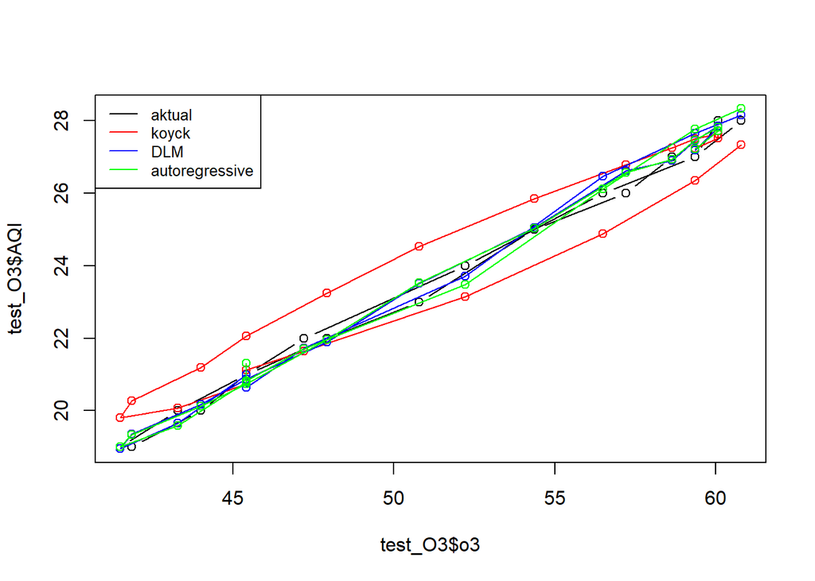

```r
par(mfrow=c(1,1))
plot(test_O3$o3, test_O3$AQI, type="b", col="black",
     ylim=range(c(test_O3$AQI,
                  fore.koyck.O3$forecasts,
                  fore.dlm10$forecasts,
                  fore.ardl.optimum$forecasts)))
points(test_O3$o3, fore.koyck.O3$forecasts, col="red")
lines(test_O3$o3, fore.koyck.O3$forecasts, col="red")
points(test_O3$o3, fore.dlm10$forecasts, col="blue")
lines(test_O3$o3, fore.dlm10$forecasts, col="blue")
points(test_O3$o3, fore.ardl.optimum$forecasts, col="green")
lines(test_O3$o3, fore.ardl.optimum$forecasts, col="green")
legend("topleft", c("aktual", "koyck", "DLM", "autoregressive"),
       lty=1, col=c("black","red","blue","green"), cex=0.8)
```